[figure not shown]

Figura 1: Extraído de https://es.m.wikipedia.org/wiki/Archivo:UTEC.jpg

# 1 **Introduccion**

## 1.1 Antecedentes

Palacio y Martinez determinaron la relación entre el Rendimiento Académico (RA) con la salud mental en los estudiantes universitarios de la Simón Bolívar. Asimismo, los resultados principales indican que el RA se correlaciona negativamente con el estado de ansiedad. Además, se encontraron promedios académicos significativamente más altos en los estudiantes que no han perdido semestre alguno y que cursan todas las asignaturas proyectadas para el mismo semestre. Con el resto de variables de estudio, no se encontraron diferencias significativas. (Palacio & Martínez, 2007: pág. 113).

Morales, Silva & Vasquez, por otra parte, encontraron que la salud mental influenciada por el Covid impacta negativamente a nivel del rendimiento académico en los estudiantes. Por la que se concluye que debe darse un mayor apoyo por parte de sus padres, docentes y autoridades universitarias, para disminuir el impacto en la salud y el rendimiento académico de los jóvenes universitarios.(Morales, Silva y Vasquez, 2021: pág.119).

## 1.2 Relevancia

Es fundamental el estudio de la salud mental porque se puede obtener alguna relación entre el rendimiento académico y su estado mental del alumno de UTEC. De este modo, describir los tipos de trastornos depresivos como la ansiedad, la depresión y el estrés que padecen los estudiantes y perjudica su desarrollo académico. Todo ello, para poder abordar este tema de forma específica y ayudar a aquellos estudiantes que sufren de dicha depresión clínica.

## 1.3 Planificación

*Abrir librerías:*

```r
library(readr)
library("DescTools")
library(car)
library(dplyr)
library(remotes)
library(readr)
library(ggplot2)
library(knitr)
library(kableExtra)
```

# 2 **Datos**

## 2.1 Proceso de recolección de datos

Los datos se obtuvieron mediante una encuesta realizada por el grupo y aprobada por la profesora acorde a los objetivos propuestos inicialmente.

## 2.2 Población, muestra y muestreo

La población de estudio es la comunidad de UTEC y la unidad muestral serán los estudiantes matriculados en el 2022-02. Asimismo, luego de recolectar todas las observaciones, el tamaño de la muestra es de 251 estudiantes. El tipo de muestreo es aleatorio simple (MAS) ,ya que nuestra muestra será escogida al azar. Del mismo modo, la representatividad consta de estudiantes de diferentes ciclos de UTEC lo que nos permitirá realizar un análisis más general

[figure not shown]

Figura 2: Extraído de https://utec.edu.pe/noticias/utec-ofrece-sus-alumnos-orientacion-y-consejeria-universitaria

## 2.3 Variables

# 3 **Limpieza de datos**

**Código para importar datos**

## 3.1 Importacion el dataset

```r
library(readxl)
D <- read_excel("D.xlsx")
View(D)
```

*Cambiar el nombre al archivo*

```r
DF <- D
```

*Revisar la data*

Con `ncol`, `nrow` y `dim` podemos tener las dimensiones de la base de datos (filas y columnas)

```r
ncol(DF) # leer el número de columnas / variables
nrow(DF) # leer la cantidad de filas / obervaciones
dim(DF) # Devuelve las dimensiones de la base de datos
```

```r
summary(DF) # Resumen del tipo de variable de la base de datos
```

*Quitar variables inservibles -> No necesitamos el correo ni la hora de llenado*

```r
DF %>% select(-'Timestamp') -> DF
DF %>% select(-'Email Address') -> DF
```

*Usaremos el comando colnames para cambiar el nombre de las columnas*

```r
colnames(DF)[1] ="Edad"
colnames(DF)[2] ="Distrito"
colnames(DF)[3] ="Carrera"
colnames(DF)[4] ="Ciclo"
colnames(DF)[5] ="Sexo"
colnames(DF)[6] ="Ocupacion"
colnames(DF)[7] ="Cantidad_de_cursos"
colnames(DF)[8] ="Horas_de_sueño"
colnames(DF)[9] ="Promedio_ponderado"
colnames(DF)[10] ="Horas_de_estudio"
colnames(DF)[11] ="C_P"
colnames(DF)[12] ="C1_P1"
colnames(DF)[13] ="C1_P2"
colnames(DF)[14] ="C1_P3"
colnames(DF)[15] ="C1_P4"
colnames(DF)[16] ="C1_P5"
colnames(DF)[17] ="C1_P6"
colnames(DF)[18] ="C1_P7"
colnames(DF)[19] ="C2_P1"
colnames(DF)[20] ="C2_P2"
colnames(DF)[21] ="C2_P3"
colnames(DF)[22] ="C2_P4"
colnames(DF)[23] ="C2_P5"
colnames(DF)[24] ="C2_P6"
colnames(DF)[25] ="C2_P7"
colnames(DF)[26] ="C2_P8"
colnames(DF)[27] ="C2_P9"
colnames(DF)[28] ="C2_P10"
colnames(DF)[29] ="C2_P11"
colnames(DF)[30] ="C2_P12"
colnames(DF)[31] ="C2_P13"
colnames(DF)[32] ="C2_P14"
colnames(DF)[33] ="C2_P15"
colnames(DF)[34] ="C2_P16"
colnames(DF)[35] ="C2_P17"
colnames(DF)[36] ="C2_P18"
colnames(DF)[37] ="C2_P19"
colnames(DF)[38] ="C2_P20"
colnames(DF)[39] ="Nivel_propio_de_estres"
colnames(DF)[40] ="C3_P1"
colnames(DF)[41] ="C3_P2"
colnames(DF)[42] ="C3_P3"
colnames(DF)[43] ="C3_P4"
colnames(DF)[44] ="C3_P5"
colnames(DF)[45] ="C3_P6"
colnames(DF)[46] ="C3_P7"
colnames(DF)[47] ="C4_P1"
colnames(DF)[48] ="C4_P2"
colnames(DF)[49] ="C4_P3"
colnames(DF)[50] ="C4_P4"
colnames(DF)[51] ="C4_P5"
colnames(DF)[52] ="C4_P6"
colnames(DF)[53] ="C4_P7"
colnames(DF)[54] ="C4_P8"
```

## 3.2 Datos completos e incompletos

```r
sum(is.na(DF)) #is.na() -> este comando detecta los datos incompletos; sum -> sumar
#Sumar la cantidad de datos incompletos
sum(!is.na(DF)) #!is.na() -> es la negación de is.na, es decir, indica los datos completos.
```

*Eliminar datos de encuesta anterior*

```r
DF <- DF[-c(1, 2, 3), ]
```

```r
sum(is.na(DF)) #is.na() -> este comando detecta los datos incompletos; sum -> sumar
```

## 3.3 Estandarizando las variables

De una cualitativa a una cuantitativa:

```r
unique(DF$C1_P1) #Permite conocer todas las formas que han respondido para la variable periodo
```

```r
DF %>% mutate(C1_P1=
       ifelse(C1_P1 == "(N) Nunca" , "0",
       ifelse(C1_P1 == "(S) Siempre" , "5",
       ifelse(C1_P1 == "(AV) Algunas veces" , "3",
       ifelse(C1_P1 == "(CN) Casi Nunca" , "2",
       ifelse(C1_P1 == "(CS) Casi siempre" , "4",
       ifelse(C1_P1 == "(RV) Rara Vez" , "1", C1_P1)))))))->DF
```

```r
DF %>% mutate(C1_P2=
       ifelse(C1_P2 == "(N) Nunca" , "0",
       ifelse(C1_P2 == "(S) Siempre" , "5",
       ifelse(C1_P2 == "(AV) Algunas veces" , "3",
       ifelse(C1_P2 == "(CN) Casi Nunca" , "2",
       ifelse(C1_P2 == "(CS) Casi siempre" , "4",
       ifelse(C1_P2 == "(RV) Rara Vez" , "1", C1_P2)))))))->DF
```

```r
DF %>% mutate(C1_P3=
       ifelse(C1_P3 == "(N) Nunca" , "0",
       ifelse(C1_P3 == "(S) Siempre" , "5",
       ifelse(C1_P3 == "(AV) Algunas veces" , "3",
       ifelse(C1_P3 == "(CN) Casi Nunca" , "2",
       ifelse(C1_P3 == "(CS) Casi siempre" , "4",
       ifelse(C1_P3 == "(RV) Rara Vez" , "1", C1_P3)))))))->DF
```

```r
DF %>% mutate(C1_P4=
       ifelse(C1_P4 == "(N) Nunca" , "0",
       ifelse(C1_P4 == "(S) Siempre" , "5",
       ifelse(C1_P4 == "(AV) Algunas veces" , "3",
       ifelse(C1_P4 == "(CN) Casi Nunca" , "2",
       ifelse(C1_P4 == "(CS) Casi siempre" , "4",
       ifelse(C1_P4 == "(RV) Rara Vez" , "1", C1_P4)))))))->DF
```

```r
DF %>% mutate(C1_P5=
       ifelse(C1_P5 == "(N) Nunca" , "0",
       ifelse(C1_P5 == "(S) Siempre" , "5",
       ifelse(C1_P5 == "(AV) Algunas veces" , "3",
       ifelse(C1_P5 == "(CN) Casi Nunca" , "2",
       ifelse(C1_P5 == "(CS) Casi siempre" , "4",
       ifelse(C1_P5 == "(RV) Rara Vez" , "1", C1_P5)))))))->DF
```

```r
DF %>% mutate(C1_P6=
       ifelse(C1_P6 == "(N) Nunca" , "0",
       ifelse(C1_P6 == "(S) Siempre" , "5",
       ifelse(C1_P6 == "(AV) Algunas veces" , "3",
       ifelse(C1_P6 == "(CN) Casi Nunca" , "2",
       ifelse(C1_P6 == "(CS) Casi siempre" , "4",
       ifelse(C1_P6 == "(RV) Rara Vez" , "1", C1_P6)))))))->DF
```

```r
DF %>% mutate(C1_P7=
       ifelse(C1_P7 == "(N) Nunca" , "0",
       ifelse(C1_P7 == "(S) Siempre" , "5",
       ifelse(C1_P7 == "(AV) Algunas veces" , "3",
       ifelse(C1_P7 == "(CN) Casi Nunca" , "2",
       ifelse(C1_P7 == "(CS) Casi siempre" , "4",
       ifelse(C1_P7 == "(RV) Rara Vez" , "1", C1_P7)))))))->DF
```

```r
unique(DF$C_P) #Permite conocer todas las formas que han respondido para la variable periodo
```

```r
DF %>% mutate(C2_P1=
       ifelse(C2_P1 == "Si" , "5", C_P))->DF
```

```r
DF %>% mutate(C2_P1=
       ifelse(C2_P1 == "Muy poco (1-2 días)" , "2",
       ifelse(C2_P1 == "Casi nunca / Nunca (menos de 1 día)" , "1",
       ifelse(C2_P1 == "Casi siempre/ Siempre (5-7 días)" , "4",
       ifelse(C2_P1 == "Algunas veces / Poco (3-4días)" , "3", C2_P1)))))->DF
```

```r
DF %>% mutate(C2_P2=
       ifelse(C2_P2 == "Muy poco (1-2 días)" , "2",
       ifelse(C2_P2 == "Casi nunca / Nunca (menos de 1 día)" , "1",
       ifelse(C2_P2 == "Casi siempre/ Siempre (5-7 días)" , "4",
       ifelse(C2_P2 == "Algunas veces / Poco (3-4días)" , "3", C2_P2)))))->DF
```

```r
DF %>% mutate(C2_P3=
      ifelse(C2_P3 == "Muy poco (1-2 días)" , "2",
       ifelse(C2_P3 == "Casi nunca / Nunca (menos de 1 día)" , "1",
       ifelse(C2_P3 == "Casi siempre/ Siempre (5-7 días)" , "4",
       ifelse(C2_P3 == "Algunas veces / Poco (3-4días)" , "3", C2_P3)))))->DF
```

```r
DF %>% mutate(C2_P4=
      ifelse(C2_P4 == "Muy poco (1-2 días)" , "2",
       ifelse(C2_P4 == "Casi nunca / Nunca (menos de 1 día)" , "1",
       ifelse(C2_P4 == "Casi siempre/ Siempre (5-7 días)" , "4",
       ifelse(C2_P4 == "Algunas veces / Poco (3-4días)" , "3", C2_P4)))))->DF
```

```r
DF %>% mutate(C2_P5=
      ifelse(C2_P5 == "Muy poco (1-2 días)" , "2",
       ifelse(C2_P5 == "Casi nunca / Nunca (menos de 1 día)" , "1",
       ifelse(C2_P5 == "Casi siempre/ Siempre (5-7 días)" , "4",
       ifelse(C2_P5 == "Algunas veces / Poco (3-4días)" , "3", C2_P5)))))->DF
```

```r
DF %>% mutate(C2_P6=
      ifelse(C2_P6 == "Muy poco (1-2 días)" , "2",
       ifelse(C2_P6 == "Casi nunca / Nunca (menos de 1 día)" , "1",
       ifelse(C2_P6 == "Casi siempre/ Siempre (5-7 días)" , "4",
       ifelse(C2_P6 == "Algunas veces / Poco (3-4días)" , "3", C2_P6)))))->DF
```

```r
DF %>% mutate(C2_P7=
      ifelse(C2_P7 == "Muy poco (1-2 días)" , "2",
       ifelse(C2_P7 == "Casi nunca / Nunca (menos de 1 día)" , "1",
       ifelse(C2_P7 == "Casi siempre/ Siempre (5-7 días)" , "4",
       ifelse(C2_P7 == "Algunas veces / Poco (3-4días)" , "3", C2_P7)))))->DF
```

```r
DF %>% mutate(C2_P8=
      ifelse(C2_P8 == "Muy poco (1-2 días)" , "2",
       ifelse(C2_P8 == "Casi nunca / Nunca (menos de 1 día)" , "1",
       ifelse(C2_P8 == "Casi siempre/ Siempre (5-7 días)" , "4",
       ifelse(C2_P8 == "Algunas veces / Poco (3-4días)" , "3", C2_P8)))))->DF
```

```r
DF %>% mutate(C2_P9=
      ifelse(C2_P9 == "Muy poco (1-2 días)" , "2",
       ifelse(C2_P9 == "Casi nunca / Nunca (menos de 1 día)" , "1",
       ifelse(C2_P9 == "Casi siempre/ Siempre (5-7 días)" , "4",
       ifelse(C2_P9 == "Algunas veces / Poco (3-4días)" , "3", C2_P9)))))->DF
```

```r
DF %>% mutate(C2_P10=
      ifelse(C2_P10 == "Muy poco (1-2 días)" , "2",
       ifelse(C2_P10 == "Casi nunca / Nunca (menos de 1 día)" , "1",
       ifelse(C2_P10 == "Casi siempre/ Siempre (5-7 días)" , "4",
       ifelse(C2_P10 == "Algunas veces / Poco (3-4días)" , "3", C2_P10)))))->DF
```

```r
DF %>% mutate(C2_P11=
      ifelse(C2_P11 == "Muy poco (1-2 días)" , "2",
       ifelse(C2_P11 == "Casi nunca / Nunca (menos de 1 día)" , "1",
       ifelse(C2_P11 == "Casi siempre/ Siempre (5-7 días)" , "4",
       ifelse(C2_P11 == "Algunas veces / Poco (3-4días)" , "3", C2_P11)))))->DF
```

```r
DF %>% mutate(C2_P12=
      ifelse(C2_P12 == "Muy poco (1-2 días)" , "2",
       ifelse(C2_P12 == "Casi nunca / Nunca (menos de 1 día)" , "1",
       ifelse(C2_P12 == "Casi siempre/ Siempre (5-7 días)" , "4",
       ifelse(C2_P12 == "Algunas veces / Poco (3-4días)" , "3", C2_P12)))))->DF
```

```r
DF %>% mutate(C2_P13=
      ifelse(C2_P13 == "Muy poco (1-2 días)" , "2",
       ifelse(C2_P13 == "Casi nunca / Nunca (menos de 1 día)" , "1",
       ifelse(C2_P13 == "Casi siempre/ Siempre (5-7 días)" , "4",
       ifelse(C2_P13 == "Algunas veces / Poco (3-4días)" , "3", C2_P13)))))->DF
```

```r
DF %>% mutate(C2_P14=
      ifelse(C2_P14 == "Muy poco (1-2 días)" , "2",
       ifelse(C2_P14 == "Casi nunca / Nunca (menos de 1 día)" , "1",
       ifelse(C2_P14 == "Casi siempre/ Siempre (5-7 días)" , "4",
       ifelse(C2_P14 == "Algunas veces / Poco (3-4días)" , "3", C2_P14)))))->DF
```

```r
DF %>% mutate(C2_P15=
      ifelse(C2_P15 == "Muy poco (1-2 días)" , "2",
       ifelse(C2_P15 == "Casi nunca / Nunca (menos de 1 día)" , "1",
       ifelse(C2_P15 == "Casi siempre/ Siempre (5-7 días)" , "4",
       ifelse(C2_P15 == "Algunas veces / Poco (3-4días)" , "3", C2_P15)))))->DF
```

```r
DF %>% mutate(C2_P16=
      ifelse(C2_P16 == "Muy poco (1-2 días)" , "2",
       ifelse(C2_P16 == "Casi nunca / Nunca (menos de 1 día)" , "1",
       ifelse(C2_P16 == "Casi siempre/ Siempre (5-7 días)" , "4",
       ifelse(C2_P16 == "Algunas veces / Poco (3-4días)" , "3", C2_P16)))))->DF
```

```r
DF %>% mutate(C2_P17=
      ifelse(C2_P17 == "Muy poco (1-2 días)" , "2",
       ifelse(C2_P17 == "Casi nunca / Nunca (menos de 1 día)" , "1",
       ifelse(C2_P17 == "Casi siempre/ Siempre (5-7 días)" , "4",
       ifelse(C2_P17 == "Algunas veces / Poco (3-4días)" , "3", C2_P17)))))->DF
```

```r
DF %>% mutate(C2_P18=
      ifelse(C2_P18 == "Muy poco (1-2 días)" , "2",
       ifelse(C2_P18 == "Casi nunca / Nunca (menos de 1 día)" , "1",
       ifelse(C2_P18 == "Casi siempre/ Siempre (5-7 días)" , "4",
       ifelse(C2_P18 == "Algunas veces / Poco (3-4días)" , "3", C2_P18)))))->DF
```

```r
DF %>% mutate(C2_P19=
      ifelse(C2_P19 == "Muy poco (1-2 días)" , "2",
       ifelse(C2_P19 == "Casi nunca / Nunca (menos de 1 día)" , "1",
       ifelse(C2_P19 == "Casi siempre/ Siempre (5-7 días)" , "4",
       ifelse(C2_P19 == "Algunas veces / Poco (3-4días)" , "3", C2_P19)))))->DF
```

```r
DF %>% mutate(C2_P20=
      ifelse(C2_P20 == "Muy poco (1-2 días)" , "2",
       ifelse(C2_P20 == "Casi nunca / Nunca (menos de 1 día)" , "1",
       ifelse(C2_P20 == "Casi siempre/ Siempre (5-7 días)" , "4",
       ifelse(C2_P20 == "Algunas veces / Poco (3-4días)" , "3", C2_P20)))))->DF
```

*Convertir la variable cuantitativa en una cualitativa*

```r
DF %>% mutate(Sexo=
       ifelse(Sexo == "1" , "Masculino",
       ifelse(Sexo == "0" , "Femenino", Sexo)))-> DF
```

*Corregir la variable Promedio ponderado* Ya tenemos los datos todos completo con numeros, pero aun no lo esta reconociendo como tal, entonces agregaremos la función as.numeric y ya podremos encontrar los indicadores de resumen de la variable.

```r
DF$Promedio_ponderado= as.numeric(DF$Promedio_ponderado)
```

*Corregir la Horas de estudio a la semana*

```r
DF %>% mutate(
  Horas_de_estudio = ifelse(Horas_de_estudio <= 10, 7*Horas_de_estudio, Horas_de_estudio)
) -> DF
range(DF$Horas_de_estudio, na.rm=TRUE)
```

```r
DF %>% mutate(
  Horas_de_sueño = ifelse(Horas_de_sueño < 3, 2*Horas_de_sueño, Horas_de_sueño)
) -> DF
range(DF$Horas_de_sueño, na.rm=TRUE)
```

*Corregir la datos del test*

```r
DF$Horas_de_estudio=as.integer(DF$Horas_de_estudio)
DF$C1_P1=as.numeric(DF$C1_P1)
DF$C1_P2=as.numeric(DF$C1_P2)
DF$C1_P3=as.numeric(DF$C1_P3)
DF$C1_P4=as.numeric(DF$C1_P4)
DF$C1_P5=as.numeric(DF$C1_P5)
DF$C1_P6=as.numeric(DF$C1_P6)
DF$C1_P7=as.numeric(DF$C1_P7)

DF$C2_P1=as.numeric(DF$C2_P1)
DF$C_P=as.numeric(DF$C_P)
DF$C2_P2=as.numeric(DF$C2_P2)
DF$C2_P3=as.numeric(DF$C2_P3)
DF$C2_P4=as.numeric(DF$C2_P4)
DF$C2_P5=as.numeric(DF$C2_P5)
DF$C2_P6=as.numeric(DF$C2_P6)
DF$C2_P7=as.numeric(DF$C2_P7)
DF$C2_P8=as.numeric(DF$C2_P8)
DF$C2_P9=as.numeric(DF$C2_P9)
DF$C2_P10=as.numeric(DF$C2_P10)
DF$C2_P11=as.numeric(DF$C2_P11)
DF$C2_P12=as.numeric(DF$C2_P12)
DF$C2_P13=as.numeric(DF$C2_P13)
DF$C2_P14=as.numeric(DF$C2_P14)
DF$C2_P15=as.numeric(DF$C2_P15)
DF$C2_P16=as.numeric(DF$C2_P16)
DF$C2_P17=as.numeric(DF$C2_P17)
DF$C2_P18=as.numeric(DF$C2_P18)
DF$C2_P19=as.numeric(DF$C2_P19)
DF$C2_P20=as.numeric(DF$C2_P20)
```

```r
C1<- transmute(DF, C1 = C1_P1+C1_P2+ C1_P3+ C1_P4+ C1_P4+ C1_P5+ C1_P6+ C1_P7)
```

```r
C2<- transmute(DF, C02 = C_P+C2_P1+C2_P2+ C2_P3+ C2_P4+ C2_P5+ C2_P6+ C2_P7+C2_P8+C2_P9+C2_P10+C2_P11+C2_P12+C2_P13+C2_P14+C2_P15+C2_P16+C2_P17+C2_P18+C2_P19+C2_P20)
```

```r
C3<- transmute(DF, C3 = C3_P1+C3_P2+ C3_P3+ C3_P4+ C3_P5+ C3_P6+ C3_P7)
```

```r
C4<- transmute(DF, C4 = C4_P1+C4_P2+ C4_P3+ C4_P4)
```

```r
C_total<- transmute(DF, C_total= C1+C2+C3+C4)
```

```r
Nivel_de_estres_clinico <- transmute(DF, C_total= C_total)
```

```r
NiveInt <- read_delim("NivelesdeestresINTERVALO.csv",
    delim = ";", escape_double = FALSE, trim_ws = TRUE)
View(NiveInt)
```

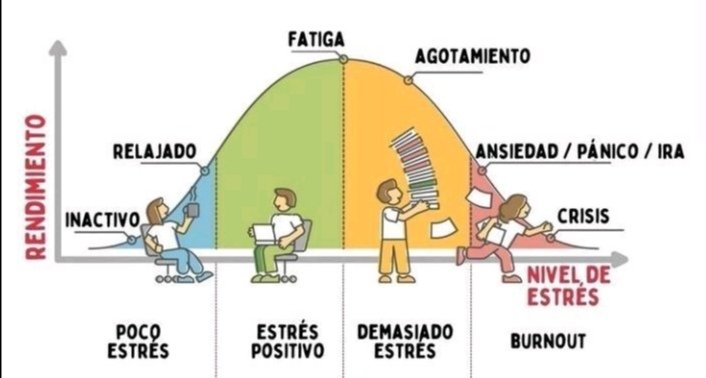

Figura 3: Extraído de https://twitter.com/pacomailkickfre/status/1470097225170800644

# 4 **Análisis descriptivo**